# Midterm - Takehome

Nikhil Gupta

2020-02-27 20:41:00

# Setup

```r
rm(list = ls()) # Remove existing variables
```

```r
# For Time Series Analysis
library(tswge)

# For Data manipulation
library(tidyverse)

# For Displaying data
library(DT)

# For plotting the data
library(patchwork)
library(ggplot2)
library(ggfortify)
```

## Common Functions

### Check Stationarity

```r
check_stationarity = function(data, title = "Time Series Plot", xlab = "Time", ylab = "Time Series Realization" ){
  # Currently, this only takes a vector (data).
  # Future Improvements: Add ability to take in Data Frames directly.

  # Setup
  x = data
  len = length(x)
  len_by_2 = round(len/2)
  seg_2_start = len_by_2+1

  # Plot Realization
  if (class(data) != "data.frame"){
    data = data.frame(Data = data, Time = seq(1:length(data)))
  }
  g1 = ggplot(data, aes(x = Time, y = Data)) + geom_line() +
    ggtitle(title) + xlab(xlab) + ylab(ylab) + theme(plot.title = element_text(hjust = 0.5))

  # Full Data ACF
  g2 = autoplot(acf(x, plot = FALSE), conf.int.fill = '#0000FF') +
    ggtitle("Full Dataset") + theme(plot.title = element_text(hjust = 0.5))

  # First Half ACF
  g3 = autoplot(acf(x[1:len_by_2], plot = FALSE), conf.int.fill = '#0000FF') +
    ggtitle("First Half") + theme(plot.title = element_text(hjust = 0.5))

  # Second Half ACF
  g4 = autoplot(acf(x[seg_2_start:len], plot = FALSE), conf.int.fill = '#0000FF') +
    ggtitle("Second Half") + theme(plot.title = element_text(hjust = 0.5))

  (g1 + g2) / (g3 + g4)  ## Requires Patchwork package

}
```

### Sliding Window ASE

```r
sliding_ase = function(x,
                       phi = 0, theta = 0, d = 0, s = 0, # ARUMA arguments
                       linear = NA, freq = NA,           # Signal + Noise arguments
                       n.ahead = NA, batch_size = NA,    # Forecasting specific arguments
                       time_index = 'test_start',        # Time Index to return ("<test|data>_<start|end>")
                       ...)                              # max.p (sigplusnoise), lambda (ARUMA)
  {
  # Sliding CV ... batches are mutually exclusive

  n = length(x)

  if (is.na(batch_size)){
    warning("Batch Size has not been specified. Will assume a single batch")
    cat("\n")
    batch_size = n
  }

  if (is.na(n.ahead)){
    stop("Number of points to be used for forecasting has not been specified. Please specify n.ahead")
  }

  if (all(phi == 0) & all(theta == 0) & d == 0 & s == 0){
    if (is.na(linear) & is.na(freq)){
      stop("You have specified the arguments for neither an ARMA/ARUMA model or a Signal + Noise Model. Please specify at least one of these to continue")
    }
  }

  aruma = FALSE
  if (!(all(phi == 0) & all(theta == 0) & d == 0 & s == 0)){
    aruma = TRUE
  }
  else{
    # Signal + Noise model
  }

  start = 1
  num_batches = n-batch_size+1
  ASEs = numeric(num_batches)
  time = numeric(num_batches)

  for (i in 0:(num_batches-1))
  {
    # Define the batch
    subset = x[start:(batch_size+i)]
    # Take last n.ahead observations from the batch and use that to compare with the forecast

    if (time_index == 'test_start'){
      time[i+1] = batch_size+i-n.ahead+1
    }
    else if (time_index == 'test_end'){
      time[i+1] = batch_size+i
    }
    else if (time_index == 'data_start'){
      time[i+1] = start
    }
    else if (time_index == 'data_end'){
      time[i+1] = batch_size+i-n.ahead
    }
    else{
      stop("You have not provided the correct time_index. Options are <data|test>_<start_end>")
    }

    test_data = x[(batch_size+i-n.ahead+1):(batch_size+i)]

    if (aruma){
      forecasts = fore.aruma.wge(x = subset, phi = phi, theta = theta, d = d, s = s,
                                 n.ahead = n.ahead, lastn = TRUE, plot = FALSE, ...)
    }
    else{
      forecasts = fore.sigplusnoise.wge(x = subset, linear = linear, freq = freq,
                                        n.ahead = n.ahead, lastn = TRUE, plot = FALSE, ...)
    }

    ASEs[i+1] = mean((test_data - forecasts$f)^2)
    start = start+1
  }

  return(list(ASEs = ASEs, time = time))
}
```

# Read Data

```r
x = read.csv("midterm2020.csv")
x %>% glimpse()
```

```
## Observations: 144
## Variables: 2
## $ X <int> 1, 2, 3, 4, 5, 6, 7, 8, 9, 10, 11, 12, 13, 14, 15, 16, 17, 1...
## $ x <int> 4250, 4400, 4350, 4500, 4550, 4500, 4050, 2250, 4450, 4650, ...
```

# EDA

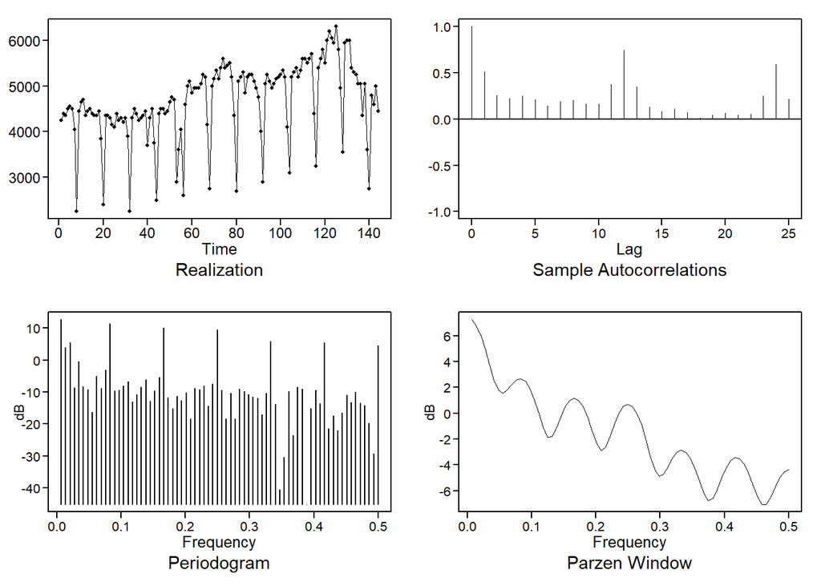

```r
x = x$x
px = plotts.sample.wge(x)
```

# Question 1

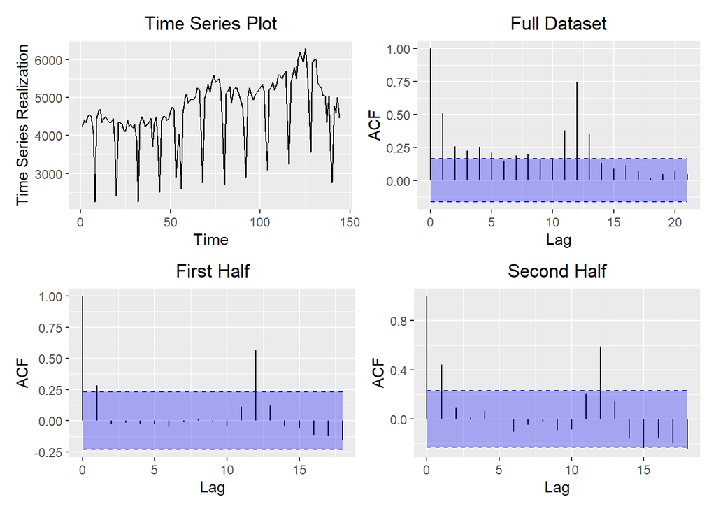

```r
check_stationarity(x)
```

```r
# Seasonality of 12
s=12
phi = c(rep(0,s-1), 1)

factor.wge(phi = phi)
```

```
##
## Coefficients of Original polynomial:
## 0.0000 0.0000 0.0000 0.0000 0.0000 0.0000 0.0000 0.0000 0.0000 0.0000 0.0000 1.0000
##
## Factor                 Roots                Abs Recip    System Freq
## 1-1.0000B+1.0000B^2    0.5000+-0.8660i      1.0000       0.1667
## 1-1.0000B              1.0000               1.0000       0.0000
## 1-1.7321B+1.0000B^2    0.8660+-0.5000i      1.0000       0.0833
## 1+1.0000B+1.0000B^2   -0.5000+-0.8660i      1.0000       0.3333
## 1-0.0000B+1.0000B^2    0.0000+-1.0000i      1.0000       0.2500
## 1+1.7321B+1.0000B^2   -0.8660+-0.5000i      1.0000       0.4167
## 1+1.0000B             -1.0000               1.0000       0.5000
##
##
```

- **Condition 1: Mean does not depend on time**
  - There seems to be seasonality in the data with s = 12. This is evident in the realization, ACF and Spectral Density. In the realization, we see the pattern repeating every 12 time points. In the ACF, we can see that data at lag = 0 is highly correlated wth data at lag = 12 and lag = 24 (more so than other lags). Even the frequencies seen in the spectral density for this realization match the frequencies seen in the true spectral density with s = 12 (from the factor table above). Since the data is changing within a seasonal period (12 consecutive data points), and we see from the realization that the data pattern (shape) is roughly same season over season, the mean looks to have a dependence on time, hence violating the 1st condition of stationarity.
  - We also see an upward trend (wandering) in the data in the second half and although it could be coming from a stationary AR process with positive phi, it could also be coming from an ARIMA type of process. This is another reason to potentially doubt that the 1st condition of stationarity has been met.
- **Condition 2: Variance does not depend on time**
  - Since we have only 1 realization, there is no way to compare multiple data points at a single time point ‘t’. Hence, it is hard to say whether the variance has a dependence on time.
  - But one thing that we can look at is the variation in data from one seasonal period to another to gauge how the variance might have varied (if we had additional realizations). If we just look at the 1st half of the dataset and observe points that are 12 time points apart, we see that the value of the data at time ‘t’ is very close to the value at time ‘t+12’ implying that the variance is small in the first half. However, if we do the same analysis in the second half, we can see that there is definitely more variance given the upward trend in this half. Again, since we have only 1 realization, it is hard to say if the variance depends on time, but given the above assessment, there is a slight hint of evidence to suggest that condition 2 may have been violated.
- **Condition 3: The correlation of $X_{t_{1}}$ and $X_{t_{2}}$ depends only on $t_{2}$ - $t_{1}$**
  - If we compare with ACF from the first half to the ACF from the second half, we see that there seasonality s = 12 shows up in both the halves (lag = 0 is highly correlated with lag = 12). This points to a roughly similar correlation structure in the 2 halves. However there is a subtle difference. As noted above, we see that there is no trend in the 1st half but a slight upward trend in the second half. This manifests itself in a higher ACF at lag = 1 in the second half vs. in the first half (suggestive of a AR process with a relatively small phi value in the second half). So there is a slight hint of difference in the ACF structure coming from the trend in the second half and this could be subtle evidence of violation of condition 3.

**CONCLUSION**

- We know with a decent amount of certainity that condition 1 is getting violated. Though we are not very sure about violation of condition 2 and 3, there is some hint that these may also be violated. When viewing the above facts in combination though, we can be fairly confident that this realization is not coming from a stationary process.

# Model Setup

## Model 1

```r
phi1 = c(0.538, 0.0606, 0.1923)
theta1 = c(0)
d1 = 0
s1 = 12
phi_s1 = c(rep(0,s1-1),1)  # s1 represented in the form of phis
```

## Model 2

```r
phi2 = c(1.0507, -0.0756)
theta2 = c(0.5927, 0.2751)
```

# Question 2

```r
# Compute the phis for model 1 taking both s and AR terms into consideration
factors = mult.wge(fac1 = phi1, fac2 = phi_s1)
all_phis1 = factors$model.coef

# Compute the psi weights for model 1
psi_weights = psi.weights.wge(phi = all_phis1, lag.max = 5)
psi_weights
```

```
## [1] 0.5380000 0.3500440 0.4132265 0.3469859 0.2790334
```

**Model in GLP form = $X_{t}$ = $a_{t}$ + 0.538 $a_{t-1}$ + 0.350044 $a_{t-2}$ + 0.4132265 $a_{t-3}$ + 0.3469859 * $a_{t-4}$**

# Question 3

- In order to check the invertibility of model 2, we need to find the factors for the MA side.
- But first, we should also check to make sure that the ARMA model is not reducible

```r
# Checking factors of AR and MA side to see if the model is reducible
factor.wge(phi = phi2)
```

```
##
## Coefficients of Original polynomial:
## 1.0507 -0.0756
##
## Factor                 Roots                Abs Recip    System Freq
## 1-0.9730B              1.0277               0.9730       0.0000
## 1-0.0777B              12.8704               0.0777       0.0000
##
##
```

```r
factor.wge(phi = theta2)
```

```
##
## Coefficients of Original polynomial:
## 0.5927 0.2751
##
## Factor                 Roots                Abs Recip    System Freq
## 1-0.8988B              1.1126               0.8988       0.0000
## 1+0.3061B             -3.2671               0.3061       0.5000
##
##
```

- The model is not reducible.
- **We also see that the roots of the MA side lie outside the unit circle. Hence the model is invertible.**

# Question 4

- In order to plot the ACF and Spectal Densities for the 2 models, we will need to generate a realization from each model. We will use a large value of ‘n’ (500) so that we get ACF and Spectral Densities that are as close to the true ACF and Spectral Densities as possible.

## Model 1

```r
x1 = gen.aruma.wge(n = 500, phi = phi1, theta = theta1, d = d1, s = s1, sn = 101)
```

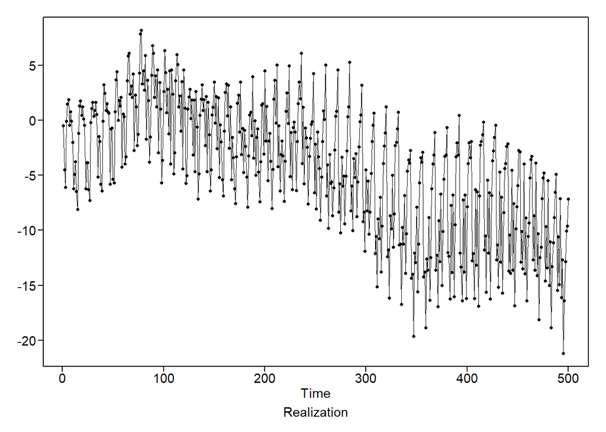

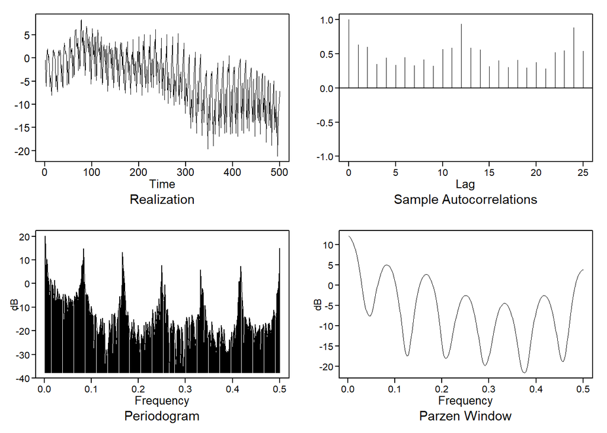

```r
px = plotts.sample.wge(x1)
```

## Model 2

```r
x2 = gen.arma.wge(n = 500, phi = phi2, theta = theta2, sn = 101)
```

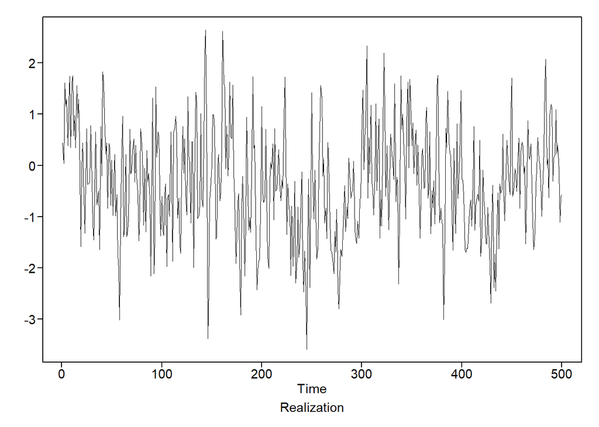

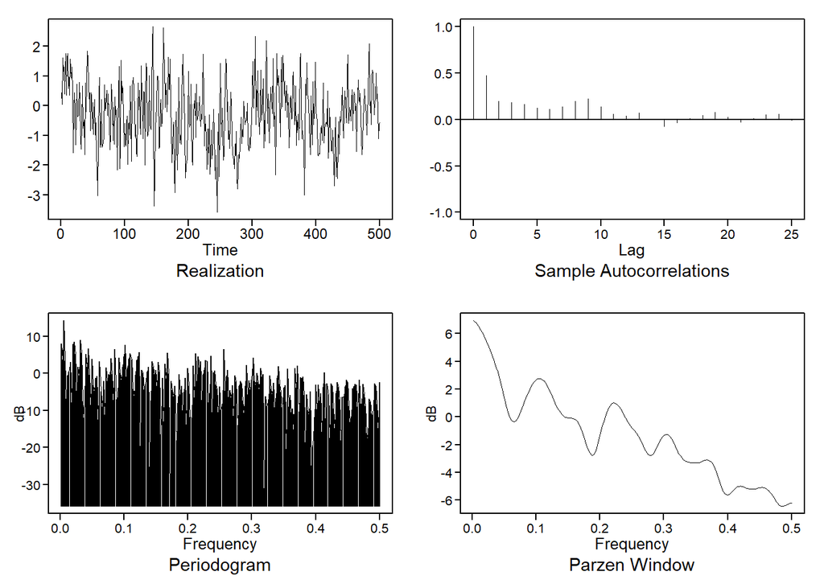

```r
px = plotts.sample.wge(x2)
```

# Question 5

## Model 1

```r
factor.wge(all_phis1)  # Factors associated with the AR, d, and s terms
```

```
##
## Coefficients of Original polynomial:
## 0.5380 0.0606 0.1923 0.0000 0.0000 0.0000 0.0000 0.0000 0.0000 0.0000 0.0000 1.0000 -0.5380 -0.0606 -0.1923
##
## Factor                 Roots                Abs Recip    System Freq
## 1-1.7321B+1.0000B^2    0.8660+-0.5000i      1.0000       0.0833
## 1-1.0000B+1.0000B^2    0.5000+-0.8660i      1.0000       0.1667
## 1+1.0000B             -1.0000               1.0000       0.5000
## 1+1.7321B+1.0000B^2   -0.8660+-0.5000i      1.0000       0.4167
## 1+0.0000B+1.0000B^2    0.0000+-1.0000i      1.0000       0.2500
## 1+1.0000B+1.0000B^2   -0.5000+-0.8660i      1.0000       0.3333
## 1-1.0000B              1.0000               1.0000       0.0000
## 1-0.8650B              1.1560               0.8650       0.0000
## 1+0.3270B+0.2223B^2   -0.7356+-1.9893i      0.4715       0.3064
##
##
```

## Model 2

- This has already been done above when checking for reducibility of the model, but repeating here for completeness.

```r
factor.wge(phi = phi2)   # Factors associated with the AR terms
```

```
##
## Coefficients of Original polynomial:
## 1.0507 -0.0756
##
## Factor                 Roots                Abs Recip    System Freq
## 1-0.9730B              1.0277               0.9730       0.0000
## 1-0.0777B              12.8704               0.0777       0.0000
##
##
```

```r
factor.wge(phi = theta2) # Factors associated with the MA terms
```

```
##
## Coefficients of Original polynomial:
## 0.5927 0.2751
##
## Factor                 Roots                Abs Recip    System Freq
## 1-0.8988B              1.1126               0.8988       0.0000
## 1+0.3061B             -3.2671               0.3061       0.5000
##
##
```

# Question 6

## Setup for calculations

```r
n = length(x)
n.ahead = 12

# Placeholder for results with rolling Window (but could hold just 1 batch if needed)
results = tribble(~model, ~ASE, ~Time)
```

## Model 1

```r
# Using sliding window function
# Default assumes only 1 batch
r = sliding_ase(x, phi = phi1, theta = theta1, d = d1, s = s1, n.ahead = n.ahead)
ASEs = r$ASEs
Time = r$time

print(paste("ASE for Model 1 (Single Batch): ", round(ASEs)))
```

```
## [1] "ASE for Model 1 (Single Batch):  1301829"
```

```r
results = results %>% add_row(model = "M1_single", ASE = ASEs, Time = Time)
```

## Model 2

```r
# Default with sliding window function
# Assumes only 1 batch, so results must match the one without sliding window (usual method) above
r = sliding_ase(x, phi = phi2, theta = theta2, n.ahead = n.ahead)
ASEs = r$ASEs
Time = r$time

print(paste("ASE for Model 2 (Single Batch): ", round(ASEs)))
```

```
## [1] "ASE for Model 2 (Single Batch):  836289"
```

```r
results = results %>% add_row(model = "M2_single", ASE = ASEs, Time = Time)
```

**CONCLUSION**

- Based on just a single ASE, model 2 seems to perform better than model 1
- However, a single ASE may not be a very robust mesaure of the performance of the model since these results can be skewed based on a small amount of data from which we are calculating the ASE.
- A rolling Window ASE is generally a more robust measure of the models prediction performance.

# Question 7

## Setup

```r
batch_size = 48
prediction_data_size = batch_size - n.ahead
```

## Model 1

```r
r = sliding_ase(x, phi=phi1, theta = theta1, d = d1, s = s1, n.ahead = n.ahead, batch_size = batch_size)
ASEs = r$ASEs
Time = r$time

results = results %>% add_row(model = "M1_multiple", ASE = ASEs, Time = Time)
```

## Model 2

```r
r = sliding_ase(x, phi = phi2, theta = theta2, n.ahead = n.ahead, batch_size = batch_size)
ASEs = r$ASEs
Time = r$time

results = results %>% add_row(model = "M2_multiple", ASE = ASEs, Time = Time)
```

## Summarize Results

```r
# Final Results
DT::datatable(results)
```

|  | model | ASE | Time |
| --- | --- | --- | --- |
| 1 | M1_single | 1301829.29871536 | 133 |
| 2 | M2_single | 836289.089004685 | 133 |
| 3 | M1_multiple | 51365.454047751 | 37 |
| 4 | M1_multiple | 56122.4158948755 | 38 |
| 5 | M1_multiple | 60074.4678164742 | 39 |
| 6 | M1_multiple | 69767.068012679 | 40 |
| 7 | M1_multiple | 179965.135781383 | 41 |
| 8 | M1_multiple | 276756.855312383 | 42 |
| 9 | M1_multiple | 338774.209776505 | 43 |
| 10 | M1_multiple | 351006.692039685 | 44 |

[output cut: 186 more lines]

```r
results %>%
  group_by(model) %>%
  summarise(ASE_mean = round(mean(ASE)),
            ASE_median = round(median(ASE)),
            ASE_sd = round(sd(ASE)),
            num_batches = n())
```

```
## # A tibble: 4 x 5
##   model       ASE_mean ASE_median ASE_sd num_batches
##   <chr>          <dbl>      <dbl>  <dbl>       <int>
## 1 M1_multiple   286923     103495 339663          97
## 2 M1_single    1301829    1301829     NA           1
## 3 M2_multiple   624679     579076 187965          97
## 4 M2_single     836289     836289     NA           1
```

**CONCLUSION**

- The mean (and median) rolling window ASE for model 1 is much lower than that of model 2 which is the opposite of what we got from the single ASE in the previous part.

# Question 8

## Model Comparison

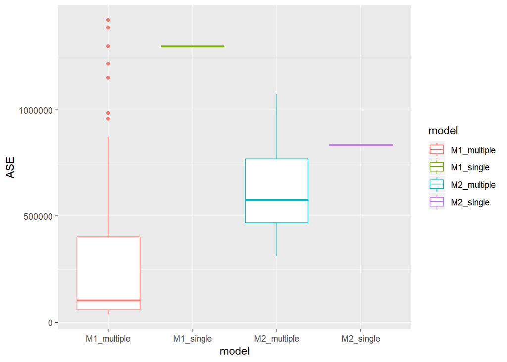

```r
ggplot(results, aes(x = model, y = ASE, color = model)) + geom_boxplot()
```

- **OBSERVATIONS**
  - The single window ASE for model 1 is larger than that for model 2.
  - However, a rolling window ASE (averaged over 97 batches) reveals that the mean (and median) ASE for model 1 is much lower than that for model 2.
  - We do however notice that model 1 has a higher variability in the ASE within the batches. Hence to determine if there is a difference between the 2 models, we can do a t-test.

## 2 sample t-test

```r
t = t.test(x = results %>% dplyr::filter(model == "M1_multiple") %>% select(ASE) %>% pluck(1),
       y = results %>% dplyr::filter(model == "M2_multiple") %>% select(ASE) %>% pluck(1),
       alternative = "two.sided", var.equal = FALSE)
t
```

```
##
##  Welch Two Sample t-test
##
## data:  results %>% dplyr::filter(model == "M1_multiple") %>% select(ASE) %>%  and results %>% dplyr::filter(model == "M2_multiple") %>% select(ASE) %>%     pluck(1) and     pluck(1)
## t = -8.569, df = 149.76, p-value = 0.00000000000001187
## alternative hypothesis: true difference in means is not equal to 0
## 95 percent confidence interval:
##  -415639.5 -259872.8
## sample estimates:
## mean of x mean of y
##  286923.1  624679.3
```

```r
point_est = t$estimate[['mean of x']] - t$estimate[['mean of y']]
```

- The above analysis reveals that there is indeed a statistically significant difference (p-value = 0) between the mean ASE of model 1 and model 2, with the point estmate of the difference between model 1 ASE and model 2 ASE = -337756 and a 95% confidence interval of [-415640 , -259873]

**CONCLUSION:**

- **The above analysis provides evidence that model 1 is better (more useful) at forecasting the next 12 months compared to model 2.**

# Question 9

- From the above analysis of the rolling window ASE, we conclude that model 1 is better at forecasting the next 12 months compared to model 2.
- In addition to the ASEs, there are also other factors that would point to model 1 being a better model for making 12 month forecasts, specifically the fact that model 1 captures the seasonality in the model much better compared to model 2 which just forecasts a value that exponentially decays to the mean (see forecast shape below).
- In addition, from question 4, we see that model 1 does a better job of generating an ACF and Spectral Density that is closer to the actual realization than model 2.
- The fact that the single ASE for model 1 was larger than that for model 2 was merely due to the fact that the last seasonal cycle was quite unusual (we can see that from the realization). However, in general, we see that model 1 performed much better than model 2 in terms of ASE.

## Model 1 Forecast Shape

```r
f = fore.aruma.wge(x, phi=phi1, theta = theta1,  d = d1, s = s1,
                   n.ahead = n.ahead, limits=FALSE, lastn = FALSE)
```

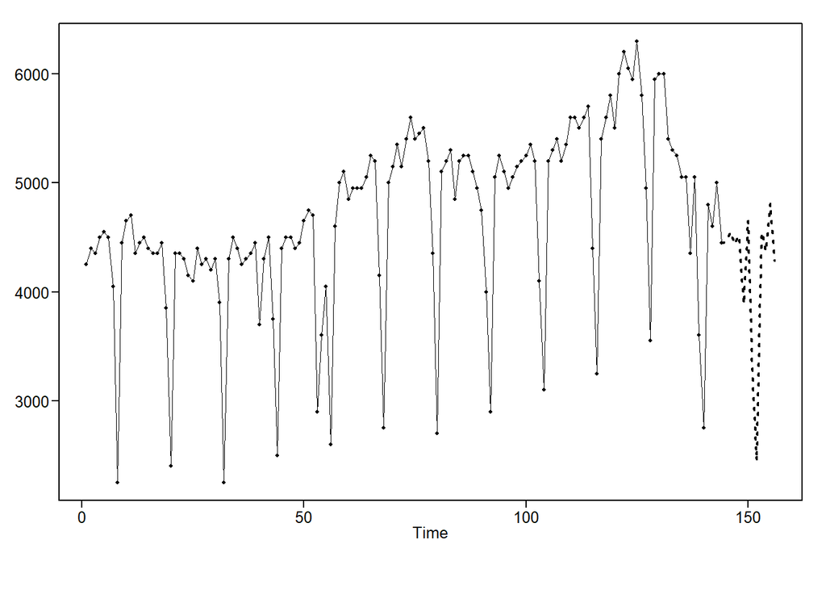

## Model 2 Forecast Shape

```r
f = fore.arma.wge(x, phi=phi2, theta = theta2,
                  n.ahead = n.ahead, limits=FALSE, lastn = FALSE)
```

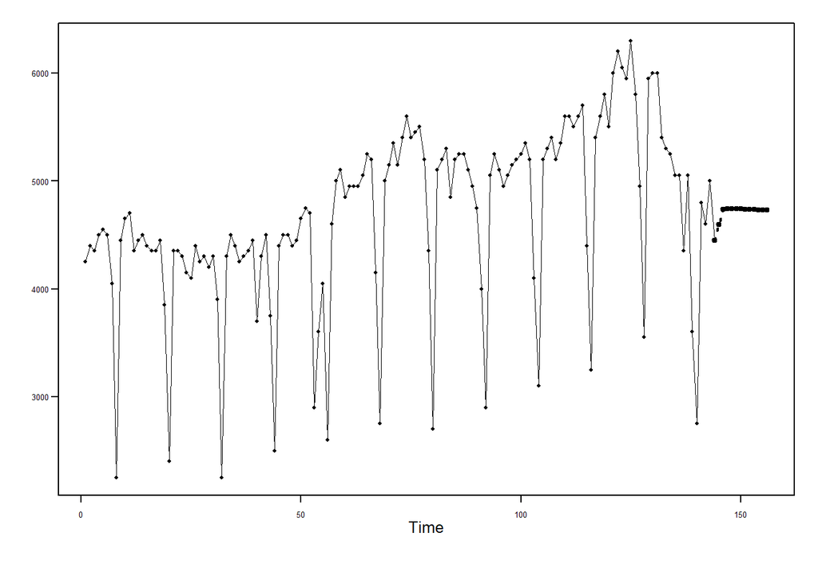

**CONCLUSION:**

- **All these factors in conjunction point to model 1 being a better overall model for forecasting the next 12 months for this data**.

# BONUS

```r
all_time = data.frame(Time = seq(1, length(x)),
                      model = c(rep("M1_multiple", length(x)), rep("M2_multiple", length(x))),
                      ASE = 0) %>%
  mutate_if(is.factor, as.character)

results2 = left_join(all_time, results, by = c("Time", "model")) %>%
  mutate(ASE = ASE.x + ASE.y)
```

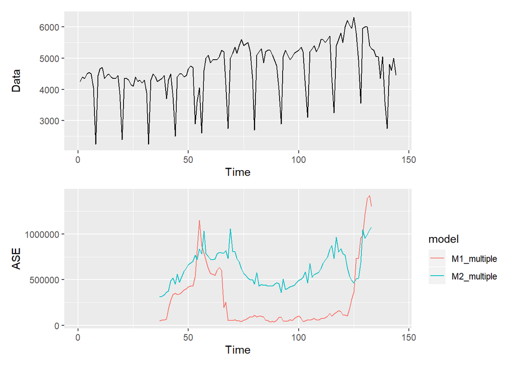

```r
data = data.frame(Time = seq(1, length(x)), Data = x)
g1 = ggplot(data, aes(x = Time, y = Data)) + geom_line()

g2 = ggplot(results2 %>% dplyr::filter(model %in% c("M1_multiple", "M2_multiple")),
            aes(x = Time, y = ASE, color = model)) +
  geom_line()

g1/g2
```

**How to read this plot**

- The above diagnostic plot shows the rolling window ASE for the 2 models vs. the data.
- The ASE value at a time point shows the ASE value for predicting the next 12 time points using the 36 points immediately preceeding this time point (i.e. Batch size is 48, with the first 36 points being used to predict the next 12).
- Since the data size used to make the window predictions is 36, we dont have any ASE values for the first 36 points. Similarly, since the last 12 data points will be used to make the last window prediction, we dont have the ASE values for these points.

**CONCLUSION**

- We see that in general, model 1 does much better than model 2 (much lower values of rolling window ASE over time).
- The only time model 1 starts performing worse is when the seasonal behavior is disrupted. We observe that at time ~ 55 and ~135, the seasonality is disrupted and at these exact points, the rolling window ASE for model 1 starts to go up.
- Apart from these points, whenever the seasonal behavior is maintained, model 1 outperforms model 2 in terms of forecasting.